# Permutation analysis

## Overview

- Random normally-generated noise
- Eye-tracking active/passive sentences
  - Additional data from Japanese
  - Auto-correlation in behaviour (why?)
  - Problems for traditional approaches
- Permutation test
  - Simulation-based approach
  - Permute the labels and see how likely you will get the correct results by chance

## On-line eye tracking data (2 seconds)

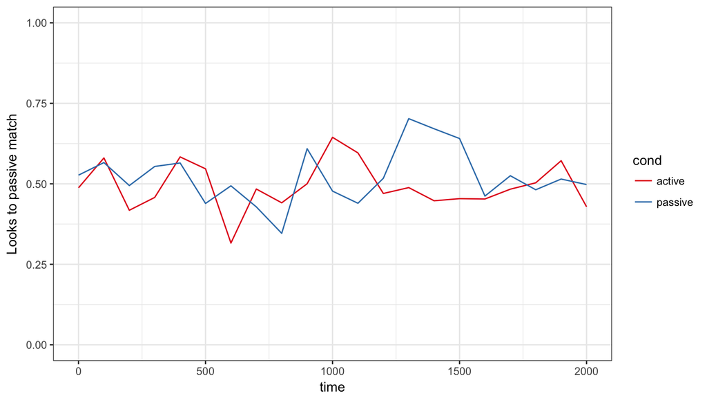

- Variability early on will reduce strength of effect

## 500 ms windows

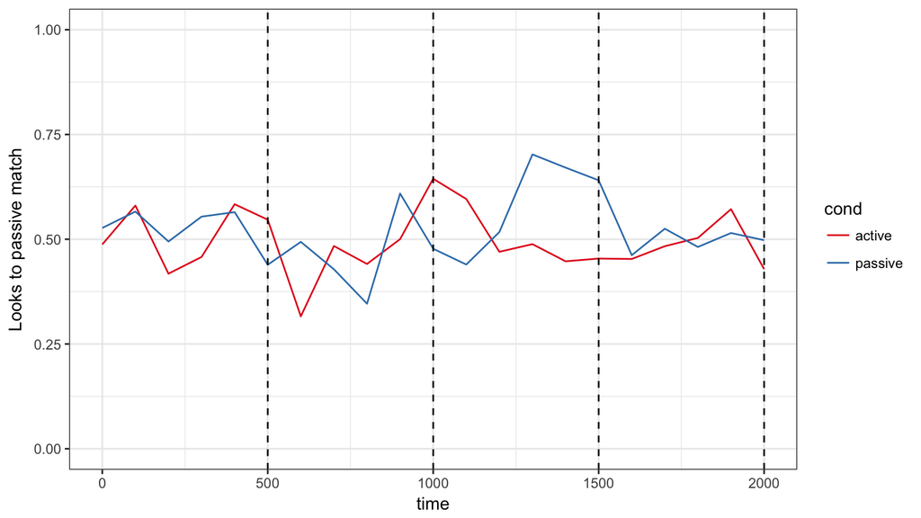

## Variable populations

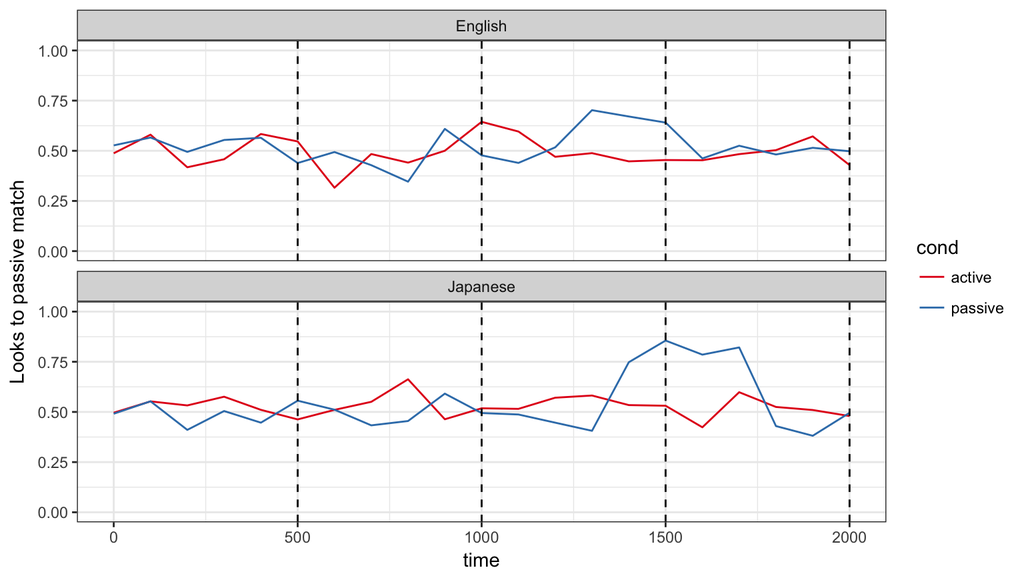

- Different populations have different windows
- Japanese effect is split across two windows

## Standard mixed model analysis

- Use 500 ms windows

```r
data$win = as.integer(-0.001+data$time/500) # divide time by 500
# aggregrate, code, and fit model
subjmeans.df = aggregate(target ~ win + lang + cond + subj, data, mean)
subjmeans.df$cwin = subjmeans.df$win - mean(subjmeans.df$win)
subjmeans.df$ceng = ifelse(subjmeans.df$lang == "English",0.5,-0.5)
subjmeans.df$cpassive = ifelse(subjmeans.df$cond == "passive",0.5,-0.5)
model = lmer(target ~ cwin*ceng*cpassive + (1 | subj), subjmeans.df)
```

```
##                      Estimate Std. Error t value
##  (Intercept)         0.520776   0.007724   67.42
##  cwin                0.007527   0.006342    1.19
##  ceng               -0.028069   0.015449   -1.82
##  cpassive            0.020313   0.014180    1.43
##  cwin:ceng          -0.017012   0.012683   -1.34
##  cwin:cpassive       0.024753   0.012683    1.95
##  ceng:cpassive       0.017907   0.028360    0.63
##  cwin:ceng:cpassive -0.029865   0.025366   -1.18
```

- absolute t-values above 2 tend to be significant

## Problem: Window variability

- Windows can change significance of results
- Windows are arbitrary
  - based on previous studies
  - removing autocorrelation
  - Few exact replications
- After looking at the data, it is possible to discover reasons for using various windows
- Different populations have different processing speeds
  - Different languages
  - Children at different ages

## Problems with a mixed model analysis

- Each window is not independent
- Time as a randoms slope (does not capture complex effect of time)

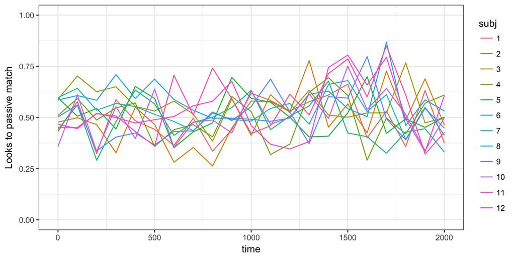

## Multiple Comparisons

- Why not just run a t-test in several windows for the English and the Japanese data?
  - Condition x window interaction?
- FMRI Resting state data 499 controls (Eklund, Nichols, & Knutsson, 2016)
  - null hypothesis (5% false positives)
  - 70% false positives
  - FMRI software does not adjust for multiple comparisons

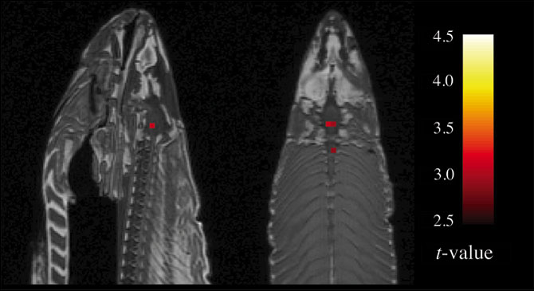

## One Solution: Permutation Analysis

- Grey windows show regions where significant difference has been found

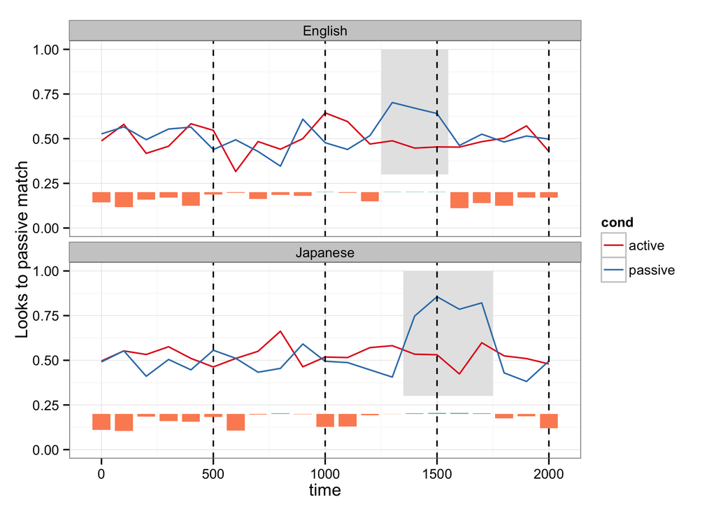

## Permutation Analysis Steps

1. Compute test statistic for each time window
2. Cluster significant windows together
3. For each time window, permute labels and test for significance.
   - Put maximal test statistic for trial in permutation distribution
4. For each cluster test if the observed test statistic is less than most of the permutation distribution

## Compute test statistic

- Test statistic: linear model
- Are active and passive different for this window?

```r
onetime = subset(pdata,time == 400 & lang == "English")
onemodel = lm(target ~ cpassive, onetime)
```

```
##              Estimate Std. Error t value Pr(>|t|)
##  (Intercept)  0.57415    0.03984  14.411 4.83e-16 ***
##  cpassive    -0.01886    0.07968  -0.237    0.814
##  ---
```

```r
print(abs(coef(summary(onemodel))[2,3]))  # get observed t value
```

```
## [1] 0.2367483
```

```r
print(abs(coef(summary(onemodel))[2,4]))  # get observed p-value
```

```
## [1] 0.8142727
```

## Compute test statistic

- p-values are orange when > 0.05
- p-values are black when <= 0.05

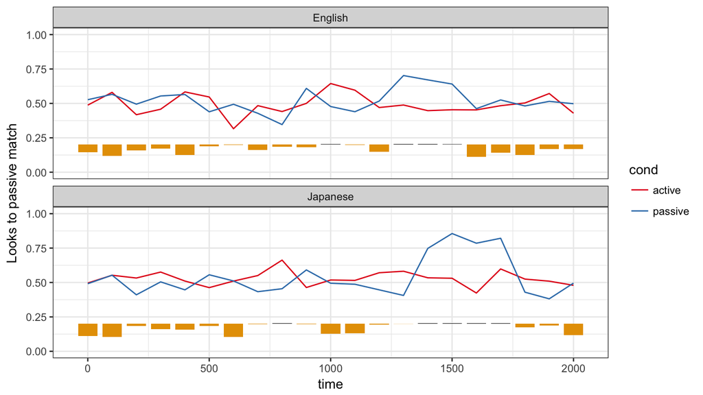

## Compute test statistic: R code

- loop over each language and each time window, and compute test statistic

```r
timelist = unique(pdata$time)
for (l in c("English","Japanese")){
  for (t in timelist){
    # create data frame for ONE timebin for each language
    onetime = subset(pdata,time == t & lang == l)
    # do regression model on target using structure condition
    onemodel = lm(target ~ cpassive, onetime)
    # this is the t-value for structure
    targetT = abs(coef(summary(onemodel))[2,3])  # observed t-value
    targetP = abs(coef(summary(onemodel))[2,4])  # observed p-value
    # save t, p in means.df
    means.df$tstr[means.df$time == t & means.df$lang == l] = targetT
    means.df$pstr[means.df$time == t & means.df$lang == l] = targetP
  }
}
# for figure, create line where 0.2 represents p=0.05
means.df$pline = 0.2+0.1*(0.05-means.df$pstr)
```

## Permutation Analysis Steps

1. Compute test statistic for each time window
2. Cluster significant windows together
3. For each time window, permute labels and test for significance.
   - Use maximal test statistic for permutation distribution
4. For each cluster test if the observed test statistic is less than most of the permutation distribution

## Clustering adjacent windows

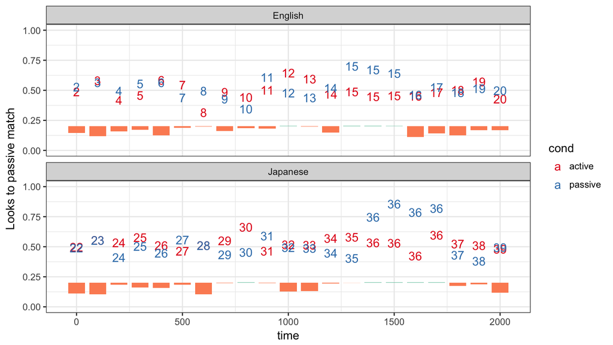

## Clustering adjacent windows

- Cluster number cnum is incremented whenever window is not significant
- Don't change cnum when previous window and present window are significant
  - Increment when entering a significant window

```r
cnum = 1
lastpval = 100
means.df$cnum = 1
for (l in c("English","Japanese")){
  for (t in timelist){
    onetime = subset(means.df,time == t & lang == l & cond == "active")
    pval = abs(onetime$pstr)
    if (pval < 0.05 & lastpval > 0.05 ){
      cnum = cnum + 1  # increase cluster number when entering a significant cluster
    }
    if (pval > 0.05 ){
      cnum = cnum + 1 # increase cluster number when not significant
    }
    lastpval = pval
    means.df$cnum[means.df$time == t & means.df$lang == l] = cnum
  }
  cnum=cnum+1  # new cluster for different languages
}
```

## Permutation Analysis Steps

1. Compute test statistic for each time window
2. Cluster significant windows together
3. For each time window, permute labels and test for significance.
   - Use maximal test statistic for permutation distribution
4. For each cluster test if the observed test statistic is less than most of the permutation distribution

## Permuting labels

- sample function random reorders labels without replacement

```r
randSet$cond = sample(randSet$cond,length(randSet$cond))
```

```
##  [1] "active"  "active"  "active"  "passive" "passive" "passive" "active"
##  [8] "active"  "active"  "passive" "passive" "passive" "active"  "active"
```

```
##  [1] "active"  "active"  "active"  "active"  "passive" "passive" "passive"
##  [8] "passive" "active"  "passive" "active"  "passive" "passive" "passive"
```

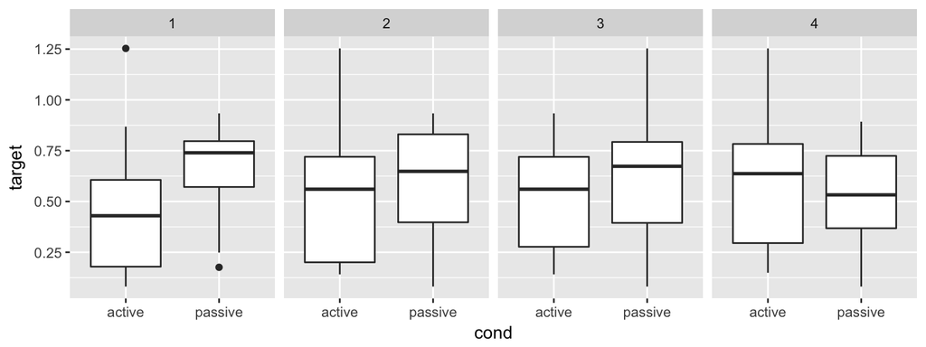

## Create permutation distribution

- create 1000 simulated experiments with permuted labels

```r
# use only significant clusters from active
meansonlyact.df = subset(means.df, cond == "active")
sigcluster = subset(meansonlyact.df, abs(pstr) < 0.05 )
n = 1000  # number of replication in distribution
exptestvalue = data.frame()  # data frame for results of distribution
# loop over every significant cluster
for (s in 1:length(sigcluster$time)){
  cl = sigcluster$cnum[s] # cluster number
  b = sigcluster$time[s] # time
  l = sigcluster$lang[s] # language
  onetime = subset(pdata,lang == l & time %in% b)   # one time point
  randSet = onetime   # randSet is a copy of onetime that is scrambled
  # create 1000 permuted models
  for (i in 1:n){
    # permute labels
    randSet$cpassive = sample(randSet$cpassive,length(randSet$cpassive))
    randmodel = lm(target ~ cpassive ,randSet) # predict target from structure
    t = coef(summary(randmodel))[2,3]     # extract and save t-values
    # save results
    df = data.frame(t=t,cluster=cl,time=b,lang=l,sim=i)
    exptestvalue = rbind(exptestvalue, df )
  }
}
```

## Cluster t values

- this is the distribution for the simulated data with random labels (null hypothesis)

```r
sumt.df =  aggregate(t ~ lang + cluster + sim, permdist, sum)
```

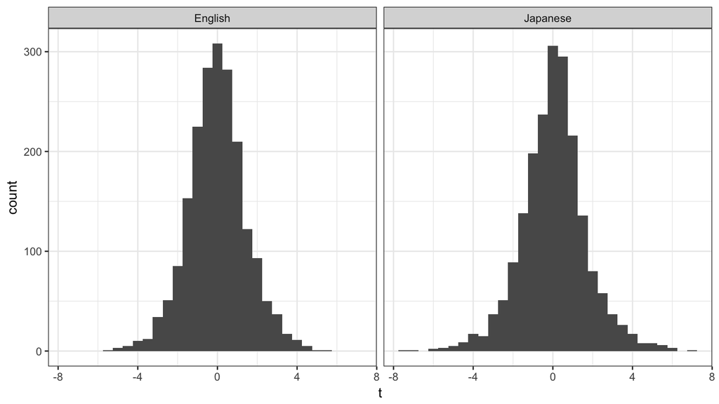

## Permutation Analysis Steps

1. Compute test statistic for each time window
2. Cluster significant windows together
3. For each time window, permute labels and test for significance
   - Use maximal test statistic for permutation distribution
4. For each cluster test if the observed test statistic is less than most of the permutation distribution

## Find maximal t-value cluster

- Our permutation distribution only has highest 1000 t-values

```r
# this code extracts out the maximum sum t for each simulation at each age
maxclusterdist = data.frame()
for (l in unique(sumt.df$lang)){
  for (s in unique(sumt.df$sim)) {
    # get all results for one simulation in one language
    onesim = subset(sumt.df,sim == s & lang == l)
    onesim$astruct = abs(onesim$t)
    # find max t-value
    maxrow = onesim[order(onesim$astruct,decreasing = T),]
    maxclusterdist = rbind(maxclusterdist,maxrow[1,])
  }
}
# maxclusterdist is sorted by language, so english is first 1000
emaxclusterdist = maxclusterdist$t[1:1000]
jmaxclusterdist = maxclusterdist$t[1001:2000] # japanese is rest
```

## Removes small t-values

- Significance is measured relative to distribution

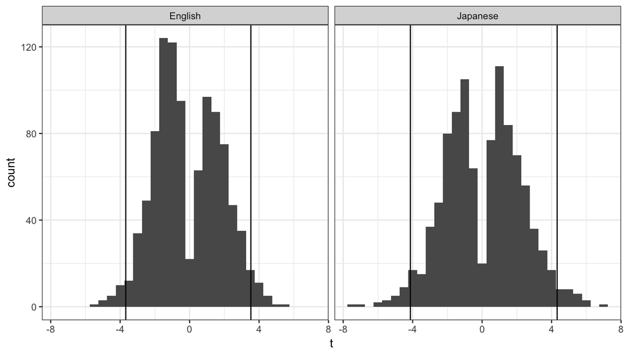

## Permutation Analysis Steps

1. Compute test statistic for each time window
2. Cluster significant windows together
3. For each time window, permute labels and test for significance
   - Use maximal test statistic for permutation distribution
4. For each cluster test if the observed test statistic is less than most of the permutation distribution

## Clusters for observed data

- We are interested in four clusters from the observed data

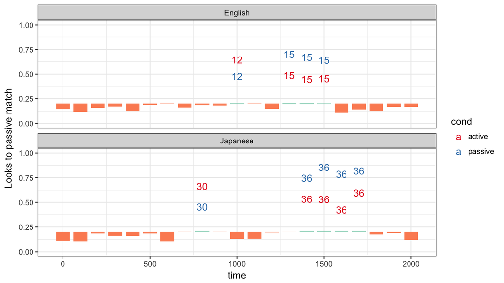

## Compute p-value

- permtdist is the distribution of cluster t-values for each language
- p-value is the proportion of values greater than observed t-value

```r
meansonlyact.df = subset(means.df, cond == "active")
sumcluster  = aggregate(tstr ~ cnum + lang, meansonlyact.df, sum)
for (cl in unique(sumcluster$cnum)){
  bins = unique(means.df[means.df$cnum == cl,]$time)
  lan = sumcluster$lang[sumcluster$cnum == cl][1]
  tstr = abs(sumcluster$tstr[sumcluster$cnum==cl])
  # permutation t distribution depends on language
  if(lan == "English"){ permtdist = emaxclusterdist} else{permtdist=jmaxclusterdist}
  pstr = sum(abs(permtdist) > tstr, na.rm = TRUE)/length(permtdist)
  means.df$permtestp[means.df$time %in% bins & means.df$lang == lan] = pstr
   if (tstr > tlevel){ print(paste("Cluster",cl,"Observed sum t",round(tstr,3),"Proportion dist > observed (p-value)",pstr)) }
}
```

```
## [1] "Cluster 12 Observed sum t 2.294 Proportion dist > observed (p-value) 0.218"
## [1] "Cluster 15 Observed sum t 7.295 Proportion dist > observed (p-value) 0"
## [1] "Cluster 30 Observed sum t 2.452 Proportion dist > observed (p-value) 0.259"
## [1] "Cluster 36 Observed sum t 13.337 Proportion dist > observed (p-value) 0"
```

## P-values

- Compare each observed cluster with perm distribution
- p value = proportion of perm dist values greater than observed value

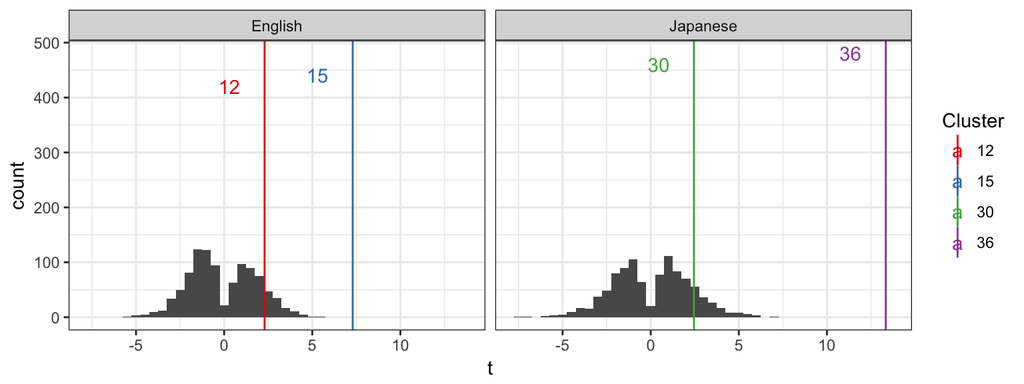

## Mark significant clusters

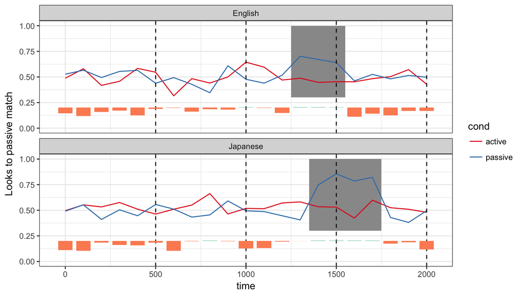

```r
meansigStr = subset(means.df,permtestp < 0.025) # two sided test
p = p + geom_rect(data=meansigStr,aes(xmin=time-50, xmax=time+50, ymin = pliney+0.1, ymax= 1.0),colour=NA,fill="grey60",show.legend=FALSE)
```

## Permutation test is magic

- Permutation test finds significant clusters in a data-driven way
- All windows are compared against full distribution, so deals with problem of multiple comparison
  - More windows -> greater chance of getting big t-value
- Dependencies between windows are captured by clusters
  - Each cluster is one processing unit
- Different populations can have different windows (e.g., languages, age groups)

## Permutation test is dangerous

- Still no consensus about how to use it
- When you take the maximal test statistic only, have you lost information from the smaller test statistics?
  - Definitely more conservative
  - How noisy is your data?
  - Do you expect multiple effects or just one?
- How do we estimate subject or item random effects?
- Complex (order is important in creating clusters)

## Readings

- **Maris, E. (2012). Statistical testing in electrophysiological studies: Statistical testing in electrophysiological studies. Psychophysiology, 49(4), 549–565**
- **Maris, E., & Oostenveld, R. (2007). Nonparametric statistical testing of EEG- and MEG-data. Journal of Neuroscience Methods, 164(1), 177–190.**
- Groppe, D. M., Urbach, T. P., & Kutas, M. (2011). Mass univariate analysis of event-related brain potentials/fields I: A critical tutorial review: Mass univariate analysis of ERPs/ERFs I: Review. Psychophysiology, 48(12), 1711–1725.
- Von Holzen, K., & Mani, N. (2012). Language nonselective lexical access in bilingual toddlers. Journal of Experimental Child Psychology, 113(4), 569–586
- Abbot-Smith, Chang, Rowland, Ferguson, & Pine (in submission) Overcoming the first-NP-as-agent bias: Preschoolers' sensitivity to passive structure
- Eklund, A., Nichols, T. E., & Knutsson, H. (2016). Cluster failure: Why fMRI inferences for spatial extent have inflated false-positive rates. Proceedings of the National Academy of Sciences, 113(28), 7900–7905.